# covid project preliminary analysis

Hyojeong(Jenny) Yoo, Juanshu(Sky) Wu, Muqing Fan, Xiangyu(Alaric) Wei, Yuchen(Eva) Liu

```r
# added a line to avoid redundant output
knitr::opts_chunk$set(warning=FALSE, message=FALSE)
```

# Introduction

# Data cleaning

Importing packages

```r
library(tidyverse)
library(dplyr)
```

## Data cleaning for CDC data

selecting relevant indices (refer to codebook)

```r
svi.raw <- read_csv("./datasets/SVI2018_US_COUNTY.csv")
svi.raw %>%
  select(STATE,
         COUNTY,
         FIPS,
         AREA_SQMI,
         E_TOTPOP,
         E_HU,
         E_HH,
         E_POV,
         E_UNEMP,
         E_PCI,
         E_NOHSDP,
         E_AGE65,
         E_DISABL,
         E_MINRTY,
         E_LIMENG,
         E_MOBILE,
         E_CROWD,
         E_NOVEH,
         E_GROUPQ,
         E_UNINSUR) -> svi.data
```

```r
svi.selected <- svi.data
svi.selected[svi.selected == "-999"] <- NA
# only New Mexico has NA responses for est. PCI, poverty, and unemployment
```

further cleaning svi data and calculating total amount of variables

```r
svi.selected %>%
  # PCI is per capita income
  # calculating total income to derive statewide per capita income later
  mutate(income = E_TOTPOP * E_PCI) %>%
  group_by(STATE) %>%
  summarise(area = sum(AREA_SQMI),
            # aggregating to state level
            total.population = sum(E_TOTPOP),
            total.housing.units = sum(E_HU),
            total.household = sum(E_HH),
            total.poverty = sum(E_POV),
            total.unemployed = sum(E_UNEMP),
            total.income = sum(income),
            # dividing into statewide per capita
            total.capita = total.income/total.population,
            total.no.HS = sum(E_NOHSDP),
            total.age65 = sum(E_AGE65),
            total.disabled = sum(E_DISABL),
            total.minority = sum(E_MINRTY),
            total.eng.proficiency = sum(E_LIMENG),
            total.mobile = sum(E_MOBILE),
            total.crowd = sum(E_CROWD),
            total.no.vehicle = sum(E_NOVEH),
            total.institutionalized = sum(E_GROUPQ),
            total.uninsured = sum(E_UNINSUR)) -> svi.state
```

further cleaning svi data and calculating percentages of variables

```r
svi.state %>%
  mutate(population.density = total.population/area,
         poverty.rate = total.poverty/total.population,
         unemployed.rate = total.unemployed/total.population,
         per.capita = total.capita,
         no.HS.rate = total.no.HS/total.population,
         age65.rate = total.age65/total.population,
         disabled.rate = total.disabled/total.population,
         minority.rate = total.minority/total.population,
         poor.English.rate = total.eng.proficiency/total.population,
         mobile.home.rate = total.mobile/total.population,
         household.crowd.rate = total.crowd/total.population,
         no.vehicle.rate = total.no.vehicle/total.population,
         institutionalized.rate = total.institutionalized/total.population,
         uninsured.rate = total.uninsured/total.population) -> svi.state


svi.state$STATE <- str_to_title(svi.state$STATE[1:51])

# write.csv(svi.state,"C:\\Users\\fan\\Desktop\\preliminary cdc data version 1.csv")
```

## JHU COVID-19 data cleaning

loading JHU covid death historical dateset

```r
covid.death.raw <- read_csv("./datasets/csse_covid_19_time_series/time_series_covid19_deaths_US.csv")
# glimpse(covid.death.raw)
```

cleaning JHU covid death historical dateset

```r
# Exclude these states
# American Samoa, Diamond Princess, Grand Princess, Guam, Northern Mariana Islands, Puerto Rico, Virgin Islands
covid.death <- covid.death.raw %>%
  select(-c(UID, iso2, iso3, code3, FIPS, Admin2, Country_Region, Lat, Long_, Combined_Key)) %>%
  rename(state = Province_State, population = Population) %>%
  group_by(state) %>% # Specify group indicator
  summarise(across(everything(), sum)) %>% # Specify column
  pivot_longer(-c(state, population),
               names_to = "date",
               values_to = "cumulative.death.cases") %>%
  filter(state %in% c(state.name, "District of Columbia")) %>%
  group_by(state) %>%
  mutate(death.cases = cumulative.death.cases - lag(cumulative.death.cases),
         date = as.Date(date, format = "%m/%d/%y"),
         month = match(months(date), month.name),
         death.cases = replace_na(death.cases, 0))

# fix negative cumulative cases
while (any(covid.death$death.cases < 0)) {
  covid.death <- covid.death %>%
    mutate(cumulative.death.cases = ifelse(cumulative.death.cases < lag(cumulative.death.cases),
                                           lag(cumulative.death.cases), # if smaller than previous
                                           cumulative.death.cases), # if not
           cumulative.death.cases = replace_na(cumulative.death.cases, 0),
           death.cases = cumulative.death.cases - lag(cumulative.death.cases),
           death.cases = replace_na(death.cases, 0))
}

covid.deaths <- covid.death[c(1, 2, 3, 6, 4, 5)]
```

loading JHU covid confirmed historical dateset

```r
covid.confirmed.raw <- read_csv("./datasets/csse_covid_19_time_series/time_series_covid19_confirmed_US.csv")
# glimpse(covid.confirmed.raw)
```

cleaning JHU covid confirmed historical dateset

```r
covid.confirmed <- covid.confirmed.raw %>%
  select(-c(UID, iso2, iso3, code3, FIPS, Admin2, Country_Region, Lat, Long_, Combined_Key)) %>%
  rename(state = Province_State) %>%
  group_by(state) %>% # Specify group indicator
  summarise(across(everything(), sum)) %>% # Specify column
  pivot_longer(-c(state),
               names_to = "date",
               values_to = "cumulative.confirmed.cases") %>%
  filter(state %in% c(state.name, "District of Columbia")) %>%
  group_by(state) %>%
  mutate(confirmed.cases = cumulative.confirmed.cases - lag(cumulative.confirmed.cases),
         date = as.Date(date, format = "%m/%d/%y"),
         confirmed.cases = replace_na(confirmed.cases, 0))

# fix negative cumulative cases
while (any(covid.confirmed$confirmed.cases < 0)) {
  covid.confirmed <- covid.confirmed %>%
    mutate(cumulative.confirmed.cases = ifelse(cumulative.confirmed.cases < lag(cumulative.confirmed.cases),
                                         lag(cumulative.confirmed.cases), # if smaller than previous
                                         cumulative.confirmed.cases), # if not
           cumulative.confirmed.cases = replace_na(cumulative.confirmed.cases, 0),
           confirmed.cases = cumulative.confirmed.cases - lag(cumulative.confirmed.cases),
           confirmed.cases = replace_na(confirmed.cases, 0))
}

# combining death and confirmed into one dataset
covid <- covid.deaths %>% inner_join(covid.confirmed, by = c("state","date"))
```

Looping through dates

```r
dates <- format(seq(from = as.Date("2020/04/13"), to = as.Date("2020/10/24"), by = "day"), "%m-%d-%Y")
date = "04-12-2020"
reports.raw <- read_csv(paste("./datasets/csse_covid_19_daily_reports_us/", date, ".csv", sep = ""))
report <- reports.raw %>%
  select(-c(Country_Region, Last_Update, Lat, Long_, Confirmed, Deaths, FIPS, UID, ISO3)) %>%
  rename(state = Province_State,
         recovered.cases = Recovered,
         active.cases = Active,
         incident.rate = Incident_Rate, # positive results per 100,000 persons.
         people.tested = People_Tested,
         people.hospitalized = People_Hospitalized,
         mortality.rate = Mortality_Rate,
         testing.rate = Testing_Rate,
         hospitalization.rate = Hospitalization_Rate) %>%
  filter(state %in% c(state.name, "District of Columbia")) %>%
  mutate(date = as.Date(date, format = "%m-%d-%y"),
         # month = match(months(date), month.name),
         incident.rate = incident.rate/1000,
         # based on documentation (100k population)
         testing.rate = testing.rate/1000) %>%
    select(-c(people.hospitalized, hospitalization.rate, recovered.cases))



for (date in dates){
  reports.raw <- read_csv(paste("./datasets/csse_covid_19_daily_reports_us/", date, ".csv", sep = ""))
  rpt <- reports.raw %>%
    select(-c(Country_Region, Last_Update, Lat, Long_, Confirmed, Deaths, FIPS, UID, ISO3)) %>%
    rename(state = Province_State,
           recovered.cases = Recovered,
           active.cases = Active,
           incident.rate = Incident_Rate,
           people.tested = People_Tested,
           people.hospitalized = People_Hospitalized,
           mortality.rate = Mortality_Rate,
           testing.rate = Testing_Rate,
           hospitalization.rate = Hospitalization_Rate) %>%
    filter(state %in% c(state.name, "District of Columbia")) %>%
    mutate(date = as.Date(date, format = "%m-%d-%y"),
           # month = match(months(date), month.name),
           incident.rate = incident.rate/1000,
           testing.rate = testing.rate/1000) %>%
    select(-c(people.hospitalized, hospitalization.rate, recovered.cases))
  ### North Dekota has > 100% testing rate
  report <- rbind(report, rpt)
}

reports <- report[c(1, 6, 7, 2, 3, 4, 5)][order(report$state, report$date),]

covid.time.series <- covid %>%
  full_join(reports, by = c("state","date")) %>%
  mutate(active.rates = 100*(active.cases / population)) # added normalized active rates

# covid.time.series <- reports
# View(covid.time.series)
#write.csv(covid.time.series, "E:/UCSD/2020-2021 Senior/PSYC 201 Project/CJHU Databse/covid time series version 1.csv")
```

## Cleaning Google mobility data

Importing Google mobility dataset

```r
US_Region_2020_mobility <- read.csv( "./datasets/2020_US_Region_Mobility_Report.csv", header=T, na.strings=c("","NA"))
```

Cleaning mobility dataset

```r
US_State_2020_mobility<- US_Region_2020_mobility %>% filter(sub_region_1 != "Null")
US_State_2020_mobility_without_county <- US_State_2020_mobility %>% filter(iso_3166_2_code != "Null")

# unique(US_State_2020_mobility_without_county$sub_region_1)
US_State_2020_mobility_without_county$date <- as.Date(US_State_2020_mobility_without_county$date, "%m/%d/%y")


month <- as.numeric(format(US_State_2020_mobility_without_county$date, "%m"))

StateMonthMobility <- US_State_2020_mobility_without_county %>% mutate(month = month)


StateMonthmobility <- StateMonthMobility %>% filter(retail_and_recreation_percent_change_from_baseline != "NA")%>%
  filter(grocery_and_pharmacy_percent_change_from_baseline != "NA")%>%
  filter(parks_percent_change_from_baseline != "NA")%>%
  filter(transit_stations_percent_change_from_baseline!= "NA")%>%
  filter(workplaces_percent_change_from_baseline!= "NA")%>%
  filter(residential_percent_change_from_baseline!= "NA")

StateMonthMobility2 <- StateMonthMobility %>%
  group_by(month,sub_region_1) %>%
  summarise(mean_retial_and_recreation_percent_change =
              mean(retail_and_recreation_percent_change_from_baseline),
            mean_grocery_and_pharmacy_percent_change =
              mean(grocery_and_pharmacy_percent_change_from_baseline),
            mean_parks_percent_change = mean(parks_percent_change_from_baseline),
            mean_transit_stations_percent_change =
              mean(transit_stations_percent_change_from_baseline),
            mean_workplaces_percent_change =
              mean(workplaces_percent_change_from_baseline),
            mean_residential_percent_change=
              mean(residential_percent_change_from_baseline))
```

# linear regression analysis

Create SVI & mortality rates data frame with mortality rates calculated by cumulative death over cumulative confirmed

```r
svi.analysis <- svi.state %>%
  select(c(STATE, poverty.rate, per.capita, no.HS.rate, age65.rate, disabled.rate, minority.rate, uninsured.rate)) %>%
  mutate(state = STATE)

covid.mortality <- covid.time.series %>%
  filter(date == as.Date("2020-10-24")) %>%
  mutate(mortality.avg = (cumulative.death.cases / cumulative.confirmed.cases)*100) %>%
  select(state, mortality.avg)

svi.mortality <- svi.analysis %>%
  inner_join(covid.mortality, by = "state") %>%
  select(-state)


# log transformation of per capita income
svi.mortality <- svi.mortality %>%
  mutate(pci.log = log10(per.capita))


# added population density
svi.pop <- svi.state %>%
  select(c(STATE, poverty.rate, per.capita, no.HS.rate, age65.rate, disabled.rate, minority.rate, uninsured.rate, population.density)) %>%
  mutate(state = STATE)

svi.mortality.pop <- svi.pop %>%
  inner_join(covid.mortality, by = "state") %>%
  select(-state)

svi.mortality.pop <- svi.mortality.pop %>%
  mutate(pci.log = log10(per.capita),
         # log transform population density?
         pop.log = log10(population.density)) %>%
  select(-c(per.capita, population.density))
```

Create mobility & active rates data frame with active rates and binning into biweekly time frame

```r
library(lubridate)
# making changing rates of covid active data
covid.active.diff <- covid.time.series %>%
  select(c(state, date, active.rates)) %>%
  group_by(state) %>%
  mutate(active.changes = active.rates - lag(active.rates))

# potential complications of different baselines for each day in the week
# making changing rates of mobility data
mobility.change <- StateMonthMobility %>%
  mutate(check.parks = parks_percent_change_from_baseline,
         check.transit = transit_stations_percent_change_from_baseline) %>%
#  fill(parks_percent_change_from_baseline) %>%
#  fill(transit_stations_percent_change_from_baseline) %>%
  mutate(retail.recration.diff = retail_and_recreation_percent_change_from_baseline - lag(retail_and_recreation_percent_change_from_baseline),
         grocery.pharmacy.diff = grocery_and_pharmacy_percent_change_from_baseline - lag(grocery_and_pharmacy_percent_change_from_baseline),
         parks.diff = parks_percent_change_from_baseline - lag(parks_percent_change_from_baseline),
         transit.diff = transit_stations_percent_change_from_baseline - lag(transit_stations_percent_change_from_baseline),
         workplaces.diff = workplaces_percent_change_from_baseline - lag(workplaces_percent_change_from_baseline),
         residential.diff = residential_percent_change_from_baseline - lag(residential_percent_change_from_baseline)) %>%
  mutate(parks.diff = ifelse(is.na(check.parks), NA, parks.diff),
         transit.diff = ifelse(is.na(check.transit), NA, transit.diff))


sum(is.na(mobility.change$parks.diff))
```

```
## [1] 530
```

```r
sum(is.na(mobility.change$parks_percent_change_from_baseline))
```

```
## [1] 440
```

```r
# parks 440 NA
# transit 135 NA


mobility.active <- merge(mobility.change, covid.active.diff, by.x = c("sub_region_1", "date"), by.y = c("state", "date"))
# active rates df
mobility.active <- mobility.active %>%
  mutate(state = sub_region_1) %>%
  select(c(state, date, retail_and_recreation_percent_change_from_baseline, grocery_and_pharmacy_percent_change_from_baseline, parks_percent_change_from_baseline, transit_stations_percent_change_from_baseline, workplaces_percent_change_from_baseline, residential_percent_change_from_baseline, active.rates)) %>%
  filter(date >= as.Date("2020-04-13")) %>%
  mutate(month = months(date),
         week = format(date, format = '%W'),
         # the following code converts to biweekly
         biweek = 14 * (as.numeric(date - min(date)) %/% 14) + min(date)) %>%
  group_by(state, biweek) %>%
  summarise(active.avg = mean(active.rates),
            retail.recreation.avg = mean(retail_and_recreation_percent_change_from_baseline),
            grocery.pharmacy.avg = mean(grocery_and_pharmacy_percent_change_from_baseline),
            parks.avg = mean(parks_percent_change_from_baseline, na.rm=TRUE),
            transit.avg = mean(transit_stations_percent_change_from_baseline, na.rm=TRUE),
            workplace.avg = mean(workplaces_percent_change_from_baseline),
            residential.avg = mean(residential_percent_change_from_baseline))

# need to marking off public holidays
# change to bi-weekly later
# use SVI to pick out top n and bottom n states
# within these states, do state by state mobility ~ covid lm
```

Linear regression for all states to check which SVI factor is significant

```r
# poverty rates
pov.mortality.lm <- lm(mortality.avg ~ poverty.rate, svi.mortality)
pov.mortality.sum <- summary(pov.mortality.lm)

# per capita
pci.mortality.lm <- lm(mortality.avg ~ per.capita, svi.mortality)
pci.mortality.sum <- summary(pci.mortality.lm)

#no HS rates
noHS.mortality.lm <- lm(mortality.avg ~ no.HS.rate, svi.mortality)
noHS.mortality.sum <- summary(noHS.mortality.lm)

#age 65/elderly rates
age.mortality.lm <- lm(mortality.avg ~ age65.rate, svi.mortality)
age.mortality.sum <- summary(age.mortality.lm)

#unisured rates
uninsured.mortality.lm <- lm(mortality.avg ~ uninsured.rate, svi.mortality)
uninsured.mortality.sum <- summary(uninsured.mortality.lm)

#minority rates
minority.mortality.lm <- lm(mortality.avg ~ minority.rate, svi.mortality)
minority.mortality.sum <- summary(minority.mortality.lm)

disabled.mortality.lm <- lm(mortality.avg ~ disabled.rate, svi.mortality)
disabled.mortality.sum <- summary(disabled.mortality.lm)

# population density
pop.mortality.lm <- lm(mortality.avg ~ pop.log, svi.mortality.pop)
pop.mortality.sum <- summary(pop.mortality.lm)
```

checking most significant SVI factor on COVID-19 mortality rates using r-squared table

```r
m0 <- lm(mortality.avg ~ 1, svi.mortality.pop)
add1(m0, lm(mortality.avg ~ ., svi.mortality.pop))
```

```
## Single term additions
##
## Model:
## mortality.avg ~ 1
##                Df Sum of Sq     RSS  AIC
## <none>                      129.304   50
## STATE          48   129.304   0.000 -Inf
## poverty.rate    1     3.512 125.792   50
## no.HS.rate      1     2.623 126.682   51
## age65.rate      1     5.710 123.594   49
## disabled.rate   1     3.307 125.997   50
## minority.rate   1     2.592 126.712   51
## uninsured.rate  1    19.390 109.914   44
## pci.log         1    38.959  90.345   34
## pop.log         1    61.790  67.514   20
```

```r
cnames <- colnames(svi.mortality.pop)
cnames1 <- cnames[cnames != 'mortality.avg']
col.rsq1 <- function(cname) summary(lm(as.formula(paste('mortality.avg ~', cname)), svi.mortality.pop))$r.squared
rsqs1 <- map_dbl(cnames1, col.rsq1)
svi.mortality.rsq <- tibble(cname = cnames1, rsq = rsqs1) %>% arrange(desc(rsq))
svi.mortality.rsq
```

```
## # A tibble: 9 x 2
##   cname             rsq
##   <chr>           <dbl>
## 1 STATE          1
## 2 pop.log        0.465
## 3 pci.log        0.301
## 4 uninsured.rate 0.149
## 5 age65.rate     0.0439
## 6 poverty.rate   0.0272
## 7 disabled.rate  0.0254
## 8 no.HS.rate     0.0192
## 9 minority.rate  0.0179
```

```r
cor.test(svi.mortality.pop$pop.log, svi.mortality.pop$pci.log)
```

```
##
##  Pearson's product-moment correlation
##
## data:  svi.mortality.pop$pop.log and svi.mortality.pop$pci.log
## t = 2.5079, df = 47, p-value = 0.01566
## alternative hypothesis: true correlation is not equal to 0
## 95 percent confidence interval:
##  0.06901947 0.56970854
## sample estimates:
##       cor
## 0.3435485
```

```r
# could revisit if there is extra time

m1 <- lm(mortality.avg ~ pop.log, svi.mortality.pop)
summary(m1)
```

```
##
## Call:
## lm(formula = mortality.avg ~ pop.log, data = svi.mortality.pop)
##
## Residuals:
##     Min      1Q  Median      3Q     Max
## -1.6519 -0.8432 -0.3585  0.6446  3.1571
##
## Coefficients:
##             Estimate Std. Error t value Pr(>|t|)
## (Intercept)  -1.1792     0.5829  -2.023   0.0487 *
## pop.log       1.8283     0.2832   6.456 5.02e-08 ***
## ---
## Signif. codes:  0 '***' 0.001 '**' 0.01 '*' 0.05 '.' 0.1 ' ' 1
##
## Residual standard error: 1.201 on 48 degrees of freedom
## Multiple R-squared:  0.4648, Adjusted R-squared:  0.4536
## F-statistic: 41.68 on 1 and 48 DF,  p-value: 5.022e-08
```

svi states to covid ~ active rates to select top five states

```r
svi.sigl.crit = 5

svi.pop.sig.top <- svi.mortality.pop %>%
  slice_max(pop.log, n = svi.sigl.crit)
svi.pop.sig.top.states = svi.pop.sig.top$STATE
# "New Jersey"    "Rhode Island"  "Massachusetts" "Connecticut"   "Maryland"

svi.pop.sig.bottom <- svi.mortality.pop %>%
  slice_min(pop.log, n = svi.sigl.crit)
svi.pop.sig.bottom.states = svi.pop.sig.bottom$STATE
# "Alaska"       "Wyoming"      "Montana"      "North Dakota" "South Dakota"
```

checking outliers for SVI data

[figure not shown]

```r
pop.graph <- ggplot(data=svi.mortality.pop,aes(x=pop.log,y=mortality.avg)) +
#  geom_jitter(colour="dark green", alpha=0.7) +
  geom_smooth(method = "lm",
              formula = y ~ x,
              col = "dark green") +
  labs(x = "population density",
       y = "COVID-19 mortality rates") +
  annotate('text', x = 0, y = 8, label = 'p = ') +
  annotate('text', x = 180, y = 8, label = pop.mortality.sum$coefficients[2,4]) +
  geom_text(aes(label = STATE), check_overlap = TRUE) +
  theme_bw() +
  ggtitle("linear regression of population density on mortality rates")

pop.graph
```

top states

```r
svi.sig.crit = 10
svi.pop.top <- svi.mortality.pop %>%
  slice_max(pop.log, n = svi.sig.crit)
svi.pop.top.states = svi.pop.top$STATE


svi.pop.top.states
```

```
##  [1] "New Jersey"    "Rhode Island"  "Massachusetts" "Connecticut"
##  [5] "Maryland"      "Delaware"      "New York"      "Florida"
##  [9] "Pennsylvania"  "Ohio"
```

```r
#  [1] "New Jersey"    "Rhode Island"  "Massachusetts" "Connecticut"   "Maryland"      "Delaware"      "New York"      "Florida"       "Pennsylvania"
# [10] "Ohio"

mobility.active.top <- mobility.active %>%
  filter(state %in% svi.pop.top.states) %>%
  group_by(state, biweek) %>%
  summarise(active.mean = active.avg,
            mobility.mean = mean(c(retail.recreation.avg, grocery.pharmacy.avg, parks.avg, transit.avg, workplace.avg, residential.avg), na.rm = TRUE),
            retail.recreation.mean = mean(retail.recreation.avg, na.rm = TRUE),
            grocery.pharmacy.mean = mean(grocery.pharmacy.avg, na.rm = TRUE),
            parks.mean = mean(parks.avg, na.rm = TRUE),
            transit.mean = mean(transit.avg, na.rm = TRUE),
            workplace.mean = mean(workplace.avg, na.rm = TRUE),
            residential.mean = mean(residential.avg, na.rm = TRUE)) %>%
  group_by(biweek) %>%
  summarise(mean.active = mean(active.mean),
            mean.mobility = mean(mobility.mean, na.rm = TRUE) ,
            mean.retail.recreation = mean(retail.recreation.mean, na.rm = TRUE),
            mean.grocery.pharmacy = mean(grocery.pharmacy.mean, na.rm = TRUE),
            mean.parks = mean(parks.mean, na.rm = TRUE),
            mean.transit = mean(transit.mean, na.rm = TRUE),
            mean.workplace = mean(workplace.mean, na.rm = TRUE),
            mean.residenstial = mean(residential.mean, na.rm = TRUE))

mobility.active.top.lm <- lm(mean.active ~ mean.mobility, data = mobility.active.top)
mobility.active.top.res <- residuals(mobility.active.top.lm)

# retail and recreation
retail.mobility.top.lm <- lm(mean.retail.recreation ~ mean.mobility, data = mobility.active.top)
retail.top.res <- residuals(retail.mobility.top.lm)
# below is lm(residual ~ residual)
retail.top.lm <- lm(mobility.active.top.res ~ retail.top.res)
retail.top.sum <- summary(retail.top.lm)
# r squared = 0.891 ***

# grocery and pharmacy
grocery.pharmacy.mobility.top.lm <- lm(mean.grocery.pharmacy ~ mean.mobility, data = mobility.active.top)
grocery.top.res <- residuals(grocery.pharmacy.mobility.top.lm)
# below is lm(residual ~ residual)
grocery.top.lm <- lm(mobility.active.top.res ~ grocery.top.res)
grocery.top.sum <- summary(grocery.top.lm)
# r squared = 0.04013 not significant

# parks
parks.mobility.top.lm <- lm(mean.parks ~ mean.mobility, data = mobility.active.top)
parks.top.res <- residuals(parks.mobility.top.lm)
# below is lm(residual ~ residual)
parks.top.lm <- lm(mobility.active.top.res ~ parks.top.res)
parks.top.sum <- summary(parks.top.lm)
# r squared = 0.7102 ***

# transit
transit.mobility.top.lm <- lm(mean.transit ~ mean.mobility, data = mobility.active.top)
transit.top.res <- residuals(transit.mobility.top.lm)
# below is lm(residual ~ residual)
transit.top.lm <- lm(mobility.active.top.res ~ transit.top.res)
transit.top.sum <- summary(transit.top.lm)
# r squared = 0.7711 ***

# workplace
workplace.mobility.top.lm <- lm(mean.workplace ~ mean.mobility, data = mobility.active.top)
workplace.top.res <- residuals(workplace.mobility.top.lm)
# below is lm(residual ~ residual)
workplace.top.lm <- lm(mobility.active.top.res ~ workplace.top.res)
workplace.top.sum <- summary(workplace.top.lm)
# r squraed = 0.8148 ***

# residential
residential.mobility.top.lm <- lm(mean.residenstial ~ mean.mobility, data = mobility.active.top)
residential.top.res <- residuals(residential.mobility.top.lm)
# below is lm(residual ~ residual)
residential.top.lm <- lm(mobility.active.top.res ~ residential.top.res)
residential.top.sum <- summary(residential.top.lm)
# r squared = 0.9056 ***
```

bottom states

```r
svi.pop.bottom <- svi.mortality.pop %>%
  slice_min(pop.log, n = svi.sig.crit)
svi.pop.bottom.states = svi.pop.bottom$STATE
svi.pop.bottom.states
```

```
##  [1] "Alaska"       "Wyoming"      "Montana"      "North Dakota" "South Dakota"
##  [6] "New Mexico"   "Idaho"        "Nebraska"     "Nevada"       "Kansas"
```

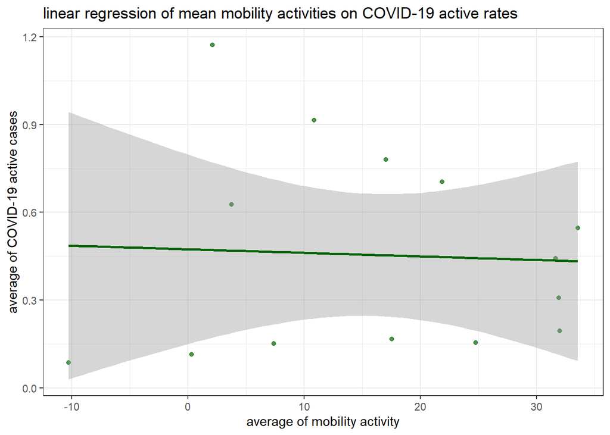

```r
#  [1] "Alaska"       "Wyoming"      "Montana"      "North Dakota" "South Dakota" "New Mexico"   "Idaho"        "Nebraska"     "Nevada"
# [10] "Kansas"

mobility.active.bottom <- mobility.active %>%
  filter(state %in% svi.pop.bottom.states) %>%
  group_by(state, biweek) %>%
  summarise(active.mean = active.avg,
            mobility.mean = mean(c(retail.recreation.avg, grocery.pharmacy.avg, parks.avg, transit.avg, workplace.avg, residential.avg), na.rm = TRUE),
            retail.recreation.mean = mean(retail.recreation.avg, na.rm = TRUE),
            grocery.pharmacy.mean = mean(grocery.pharmacy.avg, na.rm = TRUE),
            parks.mean = mean(parks.avg, na.rm = TRUE),
            transit.mean = mean(transit.avg, na.rm = TRUE),
            workplace.mean = mean(workplace.avg, na.rm = TRUE),
            residential.mean = mean(residential.avg, na.rm = TRUE)) %>%
  group_by(biweek) %>%
  summarise(mean.active = mean(active.mean),
            mean.mobility = mean(mobility.mean, na.rm = TRUE) ,
            mean.retail.recreation = mean(retail.recreation.mean, na.rm = TRUE),
            mean.grocery.pharmacy = mean(grocery.pharmacy.mean, na.rm = TRUE),
            mean.parks = mean(parks.mean, na.rm = TRUE),
            mean.transit = mean(transit.mean, na.rm = TRUE),
            mean.workplace = mean(workplace.mean, na.rm = TRUE),
            mean.residenstial = mean(residential.mean, na.rm = TRUE))


mobility.active.bottom.lm <- lm(mean.active ~ mean.mobility, data = mobility.active.bottom)
mobility.active.bottom.res <- residuals(mobility.active.bottom.lm)

# retail and recreation
retail.mobility.bottom.lm <- lm(mean.retail.recreation ~ mean.mobility, data = mobility.active.bottom)
retail.bottom.res <- residuals(retail.mobility.bottom.lm)
# below is lm(residual ~ residual)
retail.bottom.lm <- lm(mobility.active.bottom.res ~ retail.bottom.res)
retail.bottom.sum <- summary(retail.bottom.lm)
# r squared = 0.4398 ***

# grocery and pharmacy
grocery.pharmacy.mobility.bottom.lm <- lm(mean.grocery.pharmacy ~ mean.mobility, data = mobility.active.bottom)
grocery.bottom.res <- residuals(grocery.pharmacy.mobility.bottom.lm)
# below is lm(residual ~ residual)
grocery.bottom.lm <- lm(mobility.active.bottom.res ~ grocery.bottom.res)
grocery.bottom.sum <- summary(grocery.bottom.lm)
# r squared =  0.1935 not significant

# parks
parks.mobility.bottom.lm <- lm(mean.parks ~ mean.mobility, data = mobility.active.bottom)
# below is lm(residual ~ residual)
parks.bottom.res <- residuals(parks.mobility.bottom.lm)
parks.bottom.lm <- lm(mobility.active.bottom.res ~ parks.bottom.res)
parks.bottom.sum <- summary(parks.bottom.lm)
# r squared = 0.5391 **

# transit
transit.mobility.bottom.lm <- lm(mean.transit ~ mean.mobility, data = mobility.active.bottom)
# below is lm(residual ~ residual)
transit.bottom.res <- residuals(transit.mobility.bottom.lm)
transit.bottom.lm <- lm(mobility.active.bottom.res ~ transit.bottom.res)
transit.bottom.sum <- summary(transit.bottom.lm)
# r squared = 0.6077 **

# workplace
workplace.mobility.bottom.lm <- lm(mean.workplace ~ mean.mobility, data = mobility.active.bottom)
workplace.bottom.res <- residuals(workplace.mobility.bottom.lm)
# below is lm(residual ~ residual)
workplace.bottom.lm <- lm(mobility.active.bottom.res ~ workplace.bottom.res)
workplace.bottom.sum <- summary(workplace.bottom.lm)
# r squared =  0.6329 ***


# residential
residential.mobility.bottom.lm <- lm(mean.residenstial ~ mean.mobility, data = mobility.active.bottom)
residential.bottom.res <- residuals(residential.mobility.bottom.lm)
# below is lm(residual ~ residual)
residential.bottom.lm <- lm(mobility.active.bottom.res ~ residential.bottom.res)
residential.bottom.sum <- summary(residential.bottom.lm)
# r squared = 0.658 ***
residential.bottom.df <- data.frame(mobility.active.bottom.res, residential.bottom.res)



mobility.active.graph.bottom <- ggplot(data=mobility.active.bottom,aes(x=mean.mobility, y=mean.active)) +
  geom_jitter(colour="dark green", alpha=0.7) +
  geom_smooth(method = "lm",
              formula = y ~ x,
              col = "dark green") +
  labs(x = "average of mobility activity",
       y = "average of COVID-19 active cases") +
  theme_bw() +
  ggtitle("linear regression of mean mobility activities on COVID-19 active rates")



residential.bottom.graph <-
  ggplot(data=mobility.active.bottom,aes(x=mean.residenstial,y=mean.mobility)) +
  geom_jitter(colour="dark green", alpha=0.7) +
  geom_smooth(method = "lm",
              formula = y ~ x,
              col = "dark green") +
  labs(x = "average residential activity chanegs",
     y = "average of mobility activities changes") +
  theme(plot.title = element_text(size = 12),
        axis.title = element_text(size = 10)) +
  ggtitle("linear regression of residential activity chanegs to the average mobility activities changes")
# when residual of residential increase, the residual of active cases to average mobility decreases




res.residential.bottom.graph <-
    ggplot(data=residential.bottom.df,aes(x=mobility.active.bottom.res,y=residential.bottom.res)) +
    geom_jitter(colour="dark green", alpha=0.7) +
    geom_smooth(method = "lm",
              formula = y ~ x,
              col = "dark green") +
    labs(x = "residuals of mobility mean ~ residential mean",
         y = "residuals of active ~ mobility mean") +
    theme_bw() +
    ggtitle("linear regression of residential residual on mobility average residual")



mobility.active.graph.bottom
```

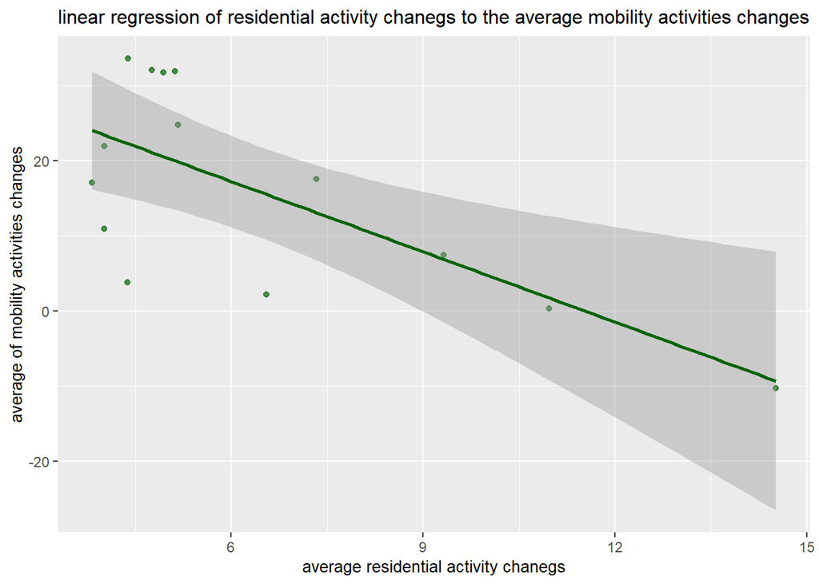

```r
residential.bottom.graph
```